# Week 5: Dimensionality and reduction techniques

```r
date()
```

```
## [1] "Sun Dec  5 16:09:10 2021"
```

This week we will analyse the *human* data set originating from the United Nations Development Programme. The data set investigates the development of a country by focusing on the citizens and their capabilities instead of the typically used economic growth. More information can be found [here](http://hdr.undp.org/en/content/human-development-index-hdi) and [here](http://hdr.undp.org/sites/default/files/hdr2015_technical_notes.pdf).

## Data exploration

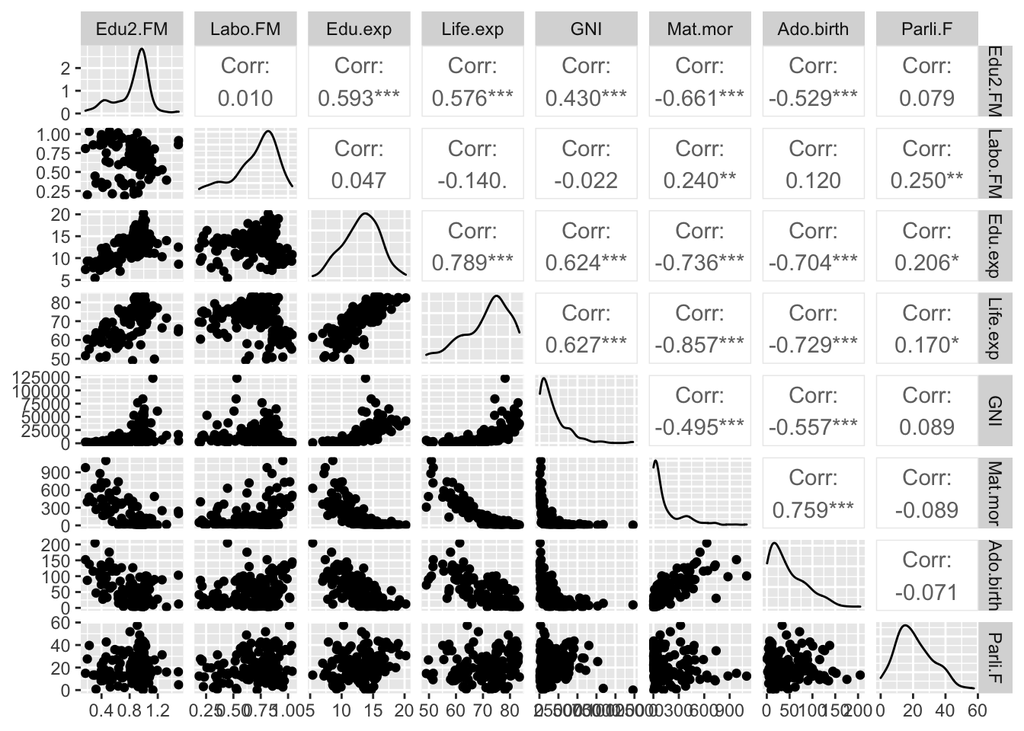

```r
# load the libraries
library(ggplot2)
library(GGally)
library(dplyr)
library(tidyverse)
# import the data
human <- read.table("Data/human.txt", sep = "\t")

# graphical overview of the data
ggpairs(human)
```

```r
# summaries
summary(human)
```

```
##     Edu2.FM          Labo.FM          Edu.exp         Life.exp
##  Min.   :0.1717   Min.   :0.1857   Min.   : 5.40   Min.   :49.00
##  1st Qu.:0.7264   1st Qu.:0.5984   1st Qu.:11.25   1st Qu.:66.30
##  Median :0.9375   Median :0.7535   Median :13.50   Median :74.20
##  Mean   :0.8529   Mean   :0.7074   Mean   :13.18   Mean   :71.65
##  3rd Qu.:0.9968   3rd Qu.:0.8535   3rd Qu.:15.20   3rd Qu.:77.25
##  Max.   :1.4967   Max.   :1.0380   Max.   :20.20   Max.   :83.50
##       GNI            Mat.mor         Ado.birth         Parli.F
##  Min.   :   581   Min.   :   1.0   Min.   :  0.60   Min.   : 0.00
##  1st Qu.:  4198   1st Qu.:  11.5   1st Qu.: 12.65   1st Qu.:12.40
##  Median : 12040   Median :  49.0   Median : 33.60   Median :19.30
##  Mean   : 17628   Mean   : 149.1   Mean   : 47.16   Mean   :20.91
##  3rd Qu.: 24512   3rd Qu.: 190.0   3rd Qu.: 71.95   3rd Qu.:27.95
##  Max.   :123124   Max.   :1100.0   Max.   :204.80   Max.   :57.50
```

Variables are explained below

- **Edu2.FM** - the ratio of female and male populations with secondary education
- **Labo.FM** - the ratio of labour force participation of females and males
- **Edu.exp** - expected years of education
- **Life.exp** - life expectancy at birth
- **GNI** - gross national income per capita
- **Mat.mor** - maternal mortality ratio
- **Ado.birth** - adolescent birth rate
- **Parli.FM** - percentage of female representation in the parliament

## Principal component analysis

```r
# PCA
pca_human <- prcomp(human)
summary(pca_human) # variability captured by the PCs
```

```
## Importance of components:
##                              PC1      PC2   PC3   PC4   PC5   PC6    PC7    PC8
## Standard deviation     1.854e+04 185.5219 25.19 11.45 3.766 1.566 0.1912 0.1591
## Proportion of Variance 9.999e-01   0.0001  0.00  0.00 0.000 0.000 0.0000 0.0000
## Cumulative Proportion  9.999e-01   1.0000  1.00  1.00 1.000 1.000 1.0000 1.0000
```

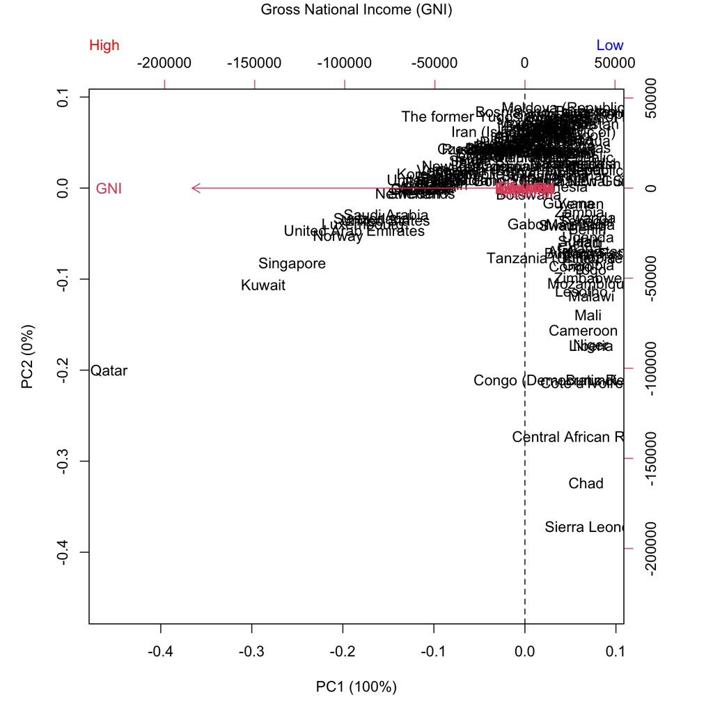

```r
# PCA biplot
# create the percentages of variance for PC1 and 2
pcs1 <- summary(pca_human)
pcs1 <- round(100*pcs1$importance[2,], digits = 1)
pcs1 <- paste0(names(pcs1), " (", pcs1, "%)")
# draw the biplot
par(mar=c(5,5,5,5)) # make larger margins
biplot(pca_human, xlab = pcs1[1], ylab = pcs1[2]) # the plot
abline(v = 0, lty = 2) # adds vertical dashed line at position 0 on the x axis
mtext(c("High", "Low", "Gross National Income (GNI)"),
      side = c(3,3,3), line = c(2,2,4), adj = c(0, 1, NA),
      col = c("red", "blue", "black")) # add text in the top margin
```

```r
# standardized values
human_std <- scale(human)

# PCA on standardized values
pca_std <- prcomp(human_std)
summary(pca_std)
```

```
## Importance of components:
##                           PC1    PC2     PC3     PC4     PC5     PC6     PC7
## Standard deviation     2.0708 1.1397 0.87505 0.77886 0.66196 0.53631 0.45900
## Proportion of Variance 0.5361 0.1624 0.09571 0.07583 0.05477 0.03595 0.02634
## Cumulative Proportion  0.5361 0.6984 0.79413 0.86996 0.92473 0.96069 0.98702
##                            PC8
## Standard deviation     0.32224
## Proportion of Variance 0.01298
## Cumulative Proportion  1.00000
```

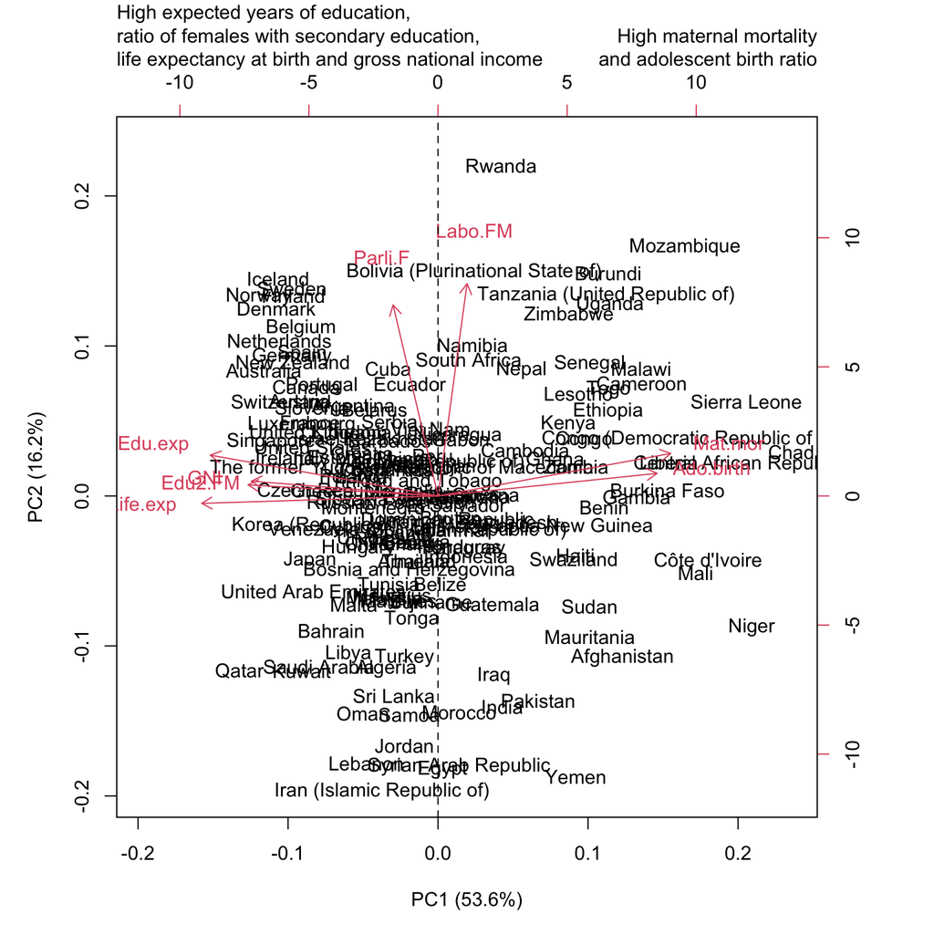

```r
# PCA biplot on standardized values
# create the percentages of variance for PC1 and 2
pcs2 <- summary(pca_std)
pcs2 <- round(100*pcs2$importance[2,], digits = 1)
pcs2 <- paste0(names(pcs2), " (", pcs2, "%)")
# draw the biplot
par(mar=c(5,5,5,5))
biplot(pca_std, xlab = pcs2[1], ylab = pcs2[2])
abline(v = 0, lty = 2)
mtext(c("High maternal mortality", "and adolescent birth ratio", "High expected years of education,", "ratio of females with secondary education,", "life expectancy at birth and gross national income"),
      side = 3, line = c(3,2,4,3,2), adj = c(1,1,0,0,0))
```

The PCA plot looks very different whether the values are standardized or not. In the first plot (not standardized) there is only one variable, the *GNI* driving the differences between countries. As we saw in the data exploration part, *GNI* shows high large variance, therefore PCA assumes that this variable is more important than the other variables with smaller variance. That’s why scaling the variables before PCA is a good idea and as seen in the second PCA plot (standardized), the result looks quite different. The standardized PCA plot indicates that countries differ from each other maternal mortality ratio, adolescent birth rate, expected years of education, ratio of females with secondary education, life expectancy at birth and gross national income according to PC1, which explains 53.6% of the variation between the countries. PC2 on the other hand separates the countries according to female/male ratio in labor force and female representation in the parliament. This explains 16.2% of the variation between the countries.

## Multiple correspondence analysis

Let’s do a multiple correcpondence analysis using the *tea* data set from the R packages [FactoMineR](http://factominer.free.fr). The data set is based on a questionnaire on tea consumption collected from 300 individuals. The data set is exploring how these individuals drink their tea and how they perceive it.

```r
# load the tea data
library(FactoMineR)
data(tea)

# structure and dimensions
dim(tea)
```

```
## [1] 300  36
```

```r
str(tea)
```

```
## 'data.frame':    300 obs. of  36 variables:
##  $ breakfast       : Factor w/ 2 levels "breakfast","Not.breakfast": 1 1 2 2 1 2 1 2 1 1 ...
##  $ tea.time        : Factor w/ 2 levels "Not.tea time",..: 1 1 2 1 1 1 2 2 2 1 ...
##  $ evening         : Factor w/ 2 levels "evening","Not.evening": 2 2 1 2 1 2 2 1 2 1 ...
##  $ lunch           : Factor w/ 2 levels "lunch","Not.lunch": 2 2 2 2 2 2 2 2 2 2 ...
##  $ dinner          : Factor w/ 2 levels "dinner","Not.dinner": 2 2 1 1 2 1 2 2 2 2 ...
##  $ always          : Factor w/ 2 levels "always","Not.always": 2 2 2 2 1 2 2 2 2 2 ...
##  $ home            : Factor w/ 2 levels "home","Not.home": 1 1 1 1 1 1 1 1 1 1 ...
##  $ work            : Factor w/ 2 levels "Not.work","work": 1 1 2 1 1 1 1 1 1 1 ...
##  $ tearoom         : Factor w/ 2 levels "Not.tearoom",..: 1 1 1 1 1 1 1 1 1 2 ...
##  $ friends         : Factor w/ 2 levels "friends","Not.friends": 2 2 1 2 2 2 1 2 2 2 ...
##  $ resto           : Factor w/ 2 levels "Not.resto","resto": 1 1 2 1 1 1 1 1 1 1 ...
##  $ pub             : Factor w/ 2 levels "Not.pub","pub": 1 1 1 1 1 1 1 1 1 1 ...
##  $ Tea             : Factor w/ 3 levels "black","Earl Grey",..: 1 1 2 2 2 2 2 1 2 1 ...
##  $ How             : Factor w/ 4 levels "alone","lemon",..: 1 3 1 1 1 1 1 3 3 1 ...
```

[output cut: 22 more lines]

All variables are factor variables (except age) and there are many (36). It was difficult to find a sensible way of visualizing this data so I jump directly into the multiple correspondence analysis part.

```r
# multiple correspondence analysis (MCA) formula
mca_tea <- MCA(tea[,-19], graph = FALSE) # leave out variable "age" since it's not categirocal
summary(mca_tea)
```

```
##
## Call:
## MCA(X = tea[, -19], graph = FALSE)
##
##
## Eigenvalues
##                        Dim.1   Dim.2   Dim.3   Dim.4   Dim.5   Dim.6   Dim.7
## Variance               0.090   0.082   0.070   0.063   0.056   0.053   0.050
## % of var.              5.838   5.292   4.551   4.057   3.616   3.465   3.272
## Cumulative % of var.   5.838  11.130  15.681  19.738  23.354  26.819  30.091
##                        Dim.8   Dim.9  Dim.10  Dim.11  Dim.12  Dim.13  Dim.14
## Variance               0.048   0.047   0.044   0.041   0.040   0.039   0.037
## % of var.              3.090   3.053   2.834   2.643   2.623   2.531   2.388
## Cumulative % of var.  33.181  36.234  39.068  41.711  44.334  46.865  49.252
##                       Dim.15  Dim.16  Dim.17  Dim.18  Dim.19  Dim.20  Dim.21
## Variance               0.036   0.035   0.034   0.032   0.031   0.031   0.030
## % of var.              2.302   2.275   2.172   2.085   2.013   2.011   1.915
## Cumulative % of var.  51.554  53.829  56.000  58.086  60.099  62.110  64.025
##                       Dim.22  Dim.23  Dim.24  Dim.25  Dim.26  Dim.27  Dim.28
## Variance               0.028   0.027   0.026   0.025   0.025   0.024   0.024
## % of var.              1.847   1.740   1.686   1.638   1.609   1.571   1.524
## Cumulative % of var.  65.872  67.611  69.297  70.935  72.544  74.115  75.639
##                       Dim.29  Dim.30  Dim.31  Dim.32  Dim.33  Dim.34  Dim.35
## Variance               0.023   0.022   0.021   0.020   0.020   0.019   0.019
## % of var.              1.459   1.425   1.378   1.322   1.281   1.241   1.222
## Cumulative % of var.  77.099  78.523  79.901  81.223  82.504  83.745  84.967
##                       Dim.36  Dim.37  Dim.38  Dim.39  Dim.40  Dim.41  Dim.42
## Variance               0.018   0.017   0.017   0.016   0.015   0.015   0.014
## % of var.              1.152   1.092   1.072   1.019   0.993   0.950   0.924
## Cumulative % of var.  86.119  87.211  88.283  89.301  90.294  91.244  92.169
##                       Dim.43  Dim.44  Dim.45  Dim.46  Dim.47  Dim.48  Dim.49
## Variance               0.014   0.013   0.012   0.011   0.011   0.010   0.010
## % of var.              0.891   0.833   0.792   0.729   0.716   0.666   0.660
## Cumulative % of var.  93.060  93.893  94.684  95.414  96.130  96.796  97.456
##                       Dim.50  Dim.51  Dim.52  Dim.53  Dim.54
## Variance               0.009   0.009   0.008   0.007   0.006
## % of var.              0.605   0.584   0.519   0.447   0.390
## Cumulative % of var.  98.060  98.644  99.163  99.610 100.000
##
## Individuals (the 10 first)
```

[output cut: 44 more lines]

```
## dinner         0.796  1.805  0.048  3.777 |
## Not.dinner    -0.060  0.136  0.048 -3.777 |
##
## Categorical variables (eta2)
##                 Dim.1 Dim.2 Dim.3
## breakfast     | 0.031 0.000 0.011 |
## tea.time      | 0.240 0.000 0.003 |
## evening       | 0.040 0.087 0.062 |
## lunch         | 0.062 0.029 0.010 |
## dinner        | 0.092 0.000 0.048 |
## always        | 0.056 0.035 0.007 |
## home          | 0.016 0.002 0.030 |
## work          | 0.075 0.020 0.022 |
## tearoom       | 0.321 0.019 0.031 |
## friends       | 0.186 0.061 0.030 |
```

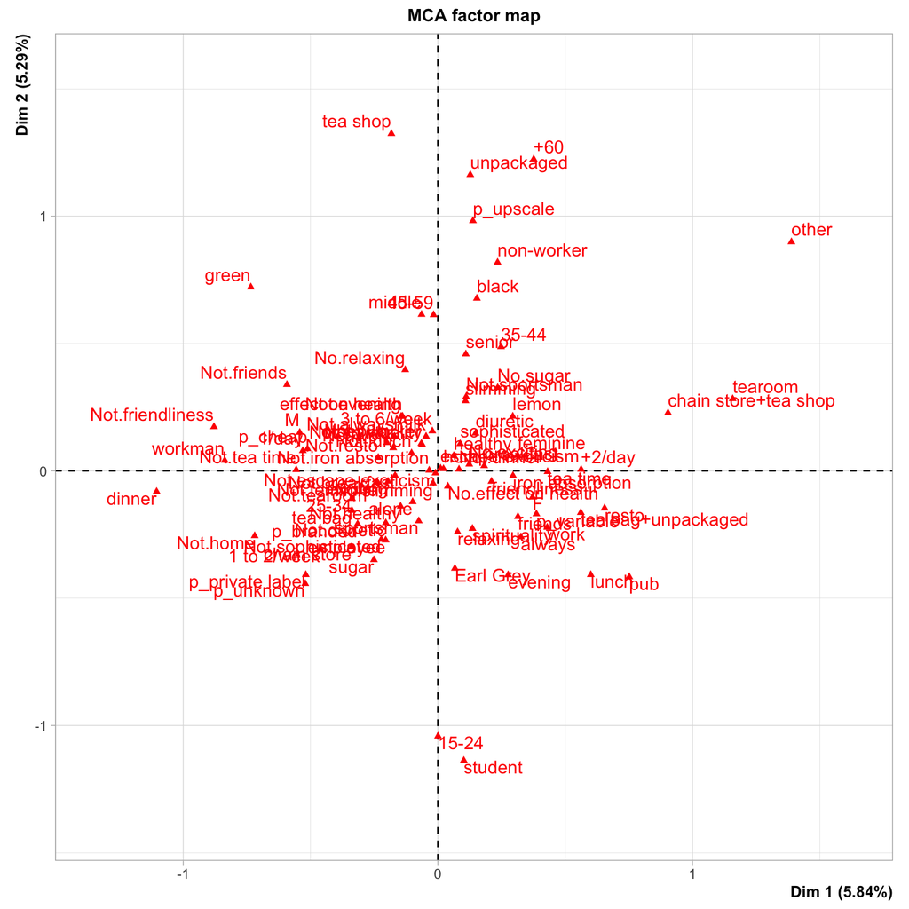

```r
# plot the results
plot(mca_tea, invisible=c("ind"))
```